# **ASSIGNMENT 2**: EXPLORATORY DATA ANALYSIS

Author**: Juan Francisco H.dez F.dez

# **Part One.**

### **Loading the dataset**

```r
datos = read.table(file = "auto-mpg.data")
```

### **Data cleaning and preparation**

```r
str(datos)
```

```
## 'data.frame':    398 obs. of  9 variables:
##  $ V1: num  18 15 18 16 17 15 14 14 14 15 ...
##  $ V2: int  8 8 8 8 8 8 8 8 8 8 ...
##  $ V3: num  307 350 318 304 302 429 454 440 455 390 ...
##  $ V4: chr  "130.0" "165.0" "150.0" "150.0" ...
##  $ V5: num  3504 3693 3436 3433 3449 ...
##  $ V6: num  12 11.5 11 12 10.5 10 9 8.5 10 8.5 ...
##  $ V7: int  70 70 70 70 70 70 70 70 70 70 ...
##  $ V8: int  1 1 1 1 1 1 1 1 1 1 ...
##  $ V9: chr  "chevrolet chevelle malibu" "buick skylark 320" "plymouth satellite" "amc rebel sst" ...
```

```r
names(datos) = c( "mpg", "cylinders", "displacement", "horsepower", "weight", "acceleration", "model year", "origin", "car name")
```

We have relabelled the data, as it was too unintuitive to read the information contained therein as it was labelled V1-V9. This way we now know what each of the integers represents.

```r
datos$horsepower <- as.numeric(as.character(datos$horsepower))
```

Because the horsepower variable was stored as a string, and we may need to operate on it later, let’s convert it to an integer.

```r
str(datos)
```

```
## 'data.frame':    398 obs. of  9 variables:
##  $ mpg         : num  18 15 18 16 17 15 14 14 14 15 ...
##  $ cylinders   : int  8 8 8 8 8 8 8 8 8 8 ...
##  $ displacement: num  307 350 318 304 302 429 454 440 455 390 ...
##  $ horsepower  : num  130 165 150 150 140 198 220 215 225 190 ...
##  $ weight      : num  3504 3693 3436 3433 3449 ...
##  $ acceleration: num  12 11.5 11 12 10.5 10 9 8.5 10 8.5 ...
##  $ model year  : int  70 70 70 70 70 70 70 70 70 70 ...
##  $ origin      : int  1 1 1 1 1 1 1 1 1 1 ...
##  $ car name    : chr  "chevrolet chevelle malibu" "buick skylark 320" "plymouth satellite" "amc rebel sst" ...
```

```r
datos <- na.omit(datos)
```

For the same reason as mentioned above, we have omited the possible NA contained in the columns of our dataset, since if it were necessary to operate with this data, the results we would obtain would be erroneous.

```r
summary(datos)
```

```
##       mpg          cylinders      displacement     horsepower        weight
##  Min.   : 9.00   Min.   :3.000   Min.   : 68.0   Min.   : 46.0   Min.   :1613
##  1st Qu.:17.00   1st Qu.:4.000   1st Qu.:105.0   1st Qu.: 75.0   1st Qu.:2225
##  Median :22.75   Median :4.000   Median :151.0   Median : 93.5   Median :2804
##  Mean   :23.45   Mean   :5.472   Mean   :194.4   Mean   :104.5   Mean   :2978
##  3rd Qu.:29.00   3rd Qu.:8.000   3rd Qu.:275.8   3rd Qu.:126.0   3rd Qu.:3615
##  Max.   :46.60   Max.   :8.000   Max.   :455.0   Max.   :230.0   Max.   :5140
##   acceleration     model year        origin        car name
##  Min.   : 8.00   Min.   :70.00   Min.   :1.000   Length:392
##  1st Qu.:13.78   1st Qu.:73.00   1st Qu.:1.000   Class :character
##  Median :15.50   Median :76.00   Median :1.000   Mode  :character
##  Mean   :15.54   Mean   :75.98   Mean   :1.577
##  3rd Qu.:17.02   3rd Qu.:79.00   3rd Qu.:2.000
##  Max.   :24.80   Max.   :82.00   Max.   :3.000
```

Here is a summary of our dataset, after we have cleaned and prepared the data. We are now ready to work with the data.

# **Part two.**

## **Let’s answer some questions related to the data**

**1.What year is the oldest car?**

```r
order(datos$`model year`)
```

[output not shown]

```r
head(datos$`model year`)[1]
```

```
## [1] 70
```

As we can see, the oldest car in our dataset dates back to 1970.

**2.The larger the displacement, the heavier the weight?**

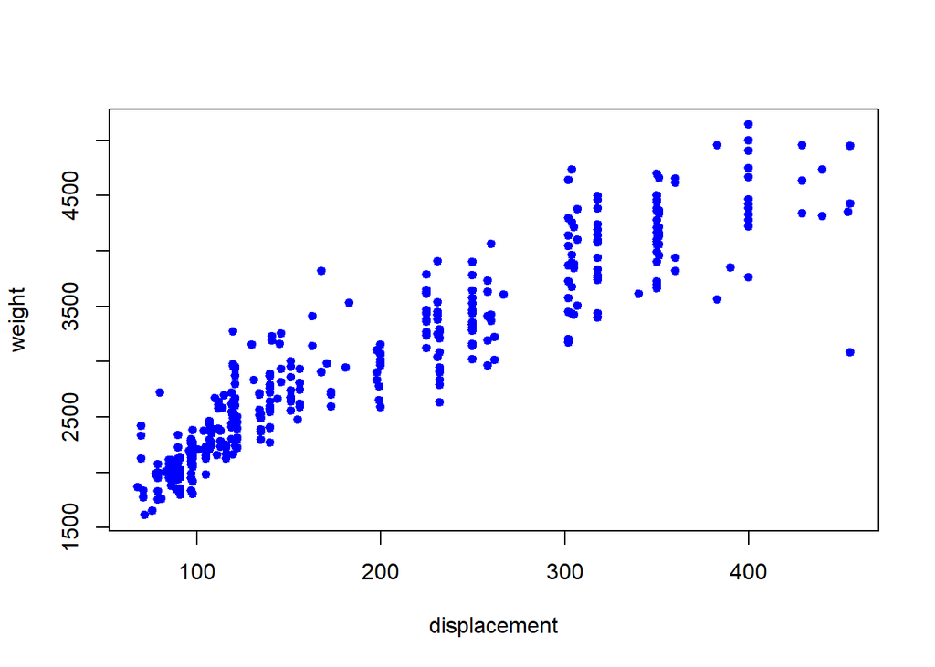

```r
plot(x = datos$displacement, y = datos$weight , col = "blue", xlab = "displacement",
     ylab = "weight", type = 'p', lwd = 2, pch=20)
```

**3.More displacement, more acceleration?**

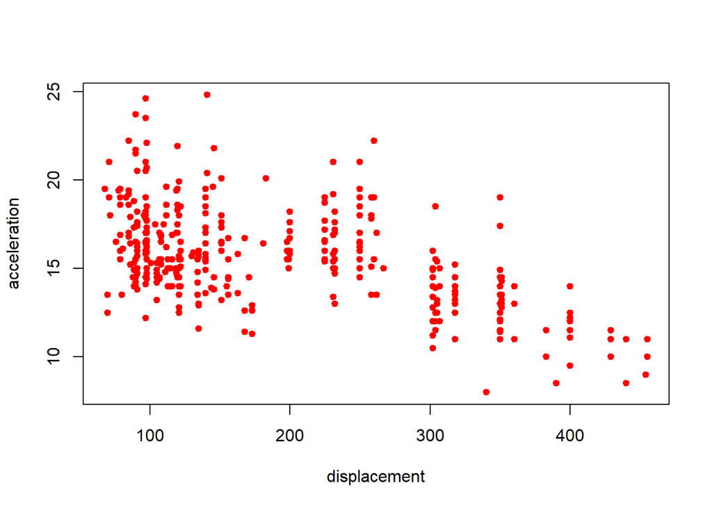

```r
plot(x = datos$displacement, y = datos$acceleration , xlab = "displacement",
     ylab = "acceleration", col = "red",type = 'p', lwd = 2, pch=20)
```

Looking at the data we can see that the larger the displacement the less acceleration, this may seem strange since in principle the displacement increases the power of the engine, however if we consider the above graph we can conclude that because the weight of the vehicle also increases with the displacement, this power does not end up translating into more acceleration.

**4.Do modern cars consume less fuel?**

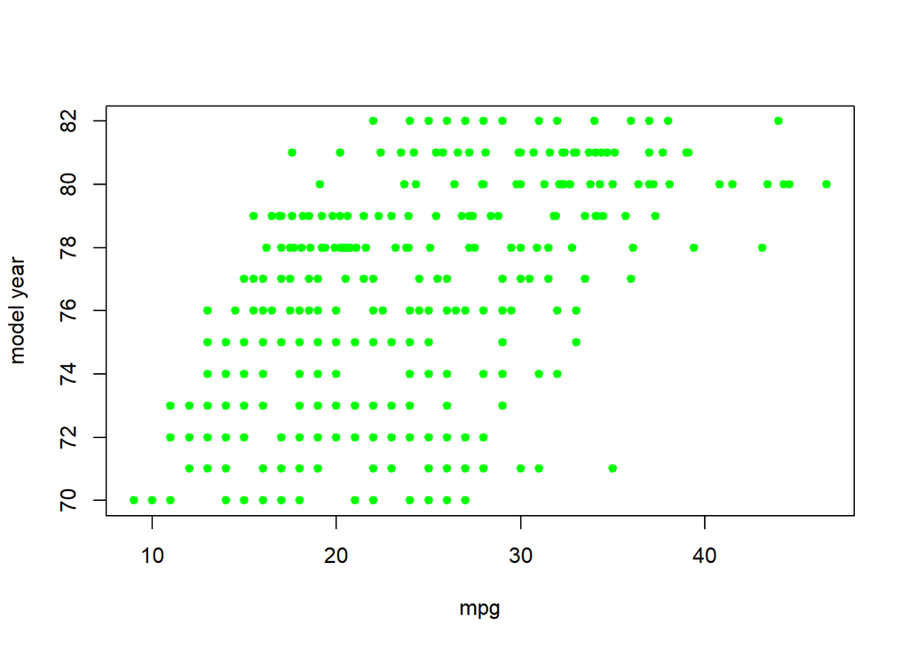

```r
plot(x = datos$mpg, y = datos$`model year`, xlab = "mpg", ylab = "model year",
     col = "green",type = 'p', lwd = 2, pch=20)
```

As can be seen in the graph, modern cars tend to be more fuel efficient, although this is not a very pronounced trend either. It should also be noted that the model year of the cars in our dataset only covers 70-82, which is probably why the trend is so smooth, perhaps if we had more current data we would see a more pronounced trend.

**5.How much does a car consume on average?**

```r
mean(datos$mpg)
```

```
## [1] 23.44592
```

To find this data we simply calculated the arithmetic mean using the mean function. The result obtained was 23.44592, so cars registered from 1970 to 1982 consumed on average 23.44592 mpg.

# **Part three.**

## **The variables**

#### **MPG**

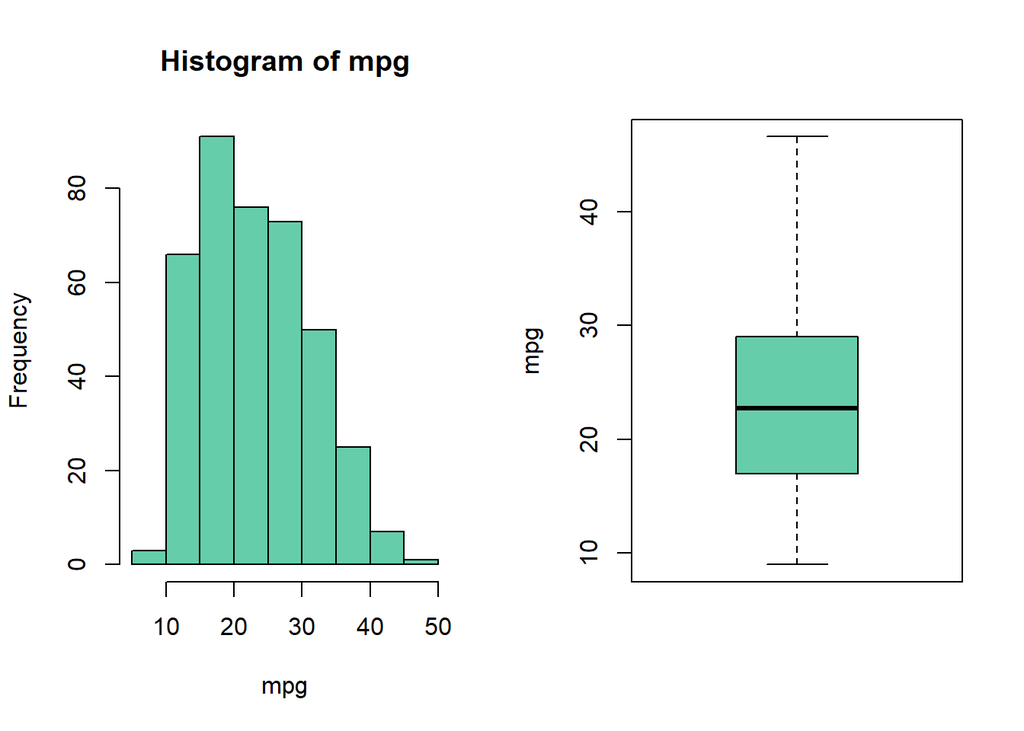

```r
par(mfrow = c(1, 2))
hist(datos$mpg, xlab = "mpg", main = "Histogram of mpg", col = ("aquamarine3") )
boxplot(datos$mpg, ylab = "mpg", col = ("aquamarine3"))
```

```r
VMe1 <- mean(abs(datos$mpg-median(datos$mpg))) /median(datos$mpg)
sprintf("The dispersion index is: %s",VMe1)
```

```
## [1] "The dispersion index is: 0.286768333707109"
```

To check the dispersion of the variables we use the dispersion index with respect to the median. This index measures the number of times that the median is contained in the deviation with respect to the median of the distribution, so that larger values indicate a greater dispersion and therefore a lower representativeness of the median. The formula for calculating this index is as follows:

$$VMe=\frac{\sum| Xi-Me |*ni}{N*Me}.$$
Applying this formula we have obtained a dispersion index of 0.286768333707109 with respect to the median. We can therefore say that the data have little dispersion. As for the centre, if we look at the boxplot, we can see that the mean of the data is around 23 mpg, as we had obtained previously. As for the symmetry of the data, looking at the histogram we can see that the representation of the data is quite symmetrical, some asymmetries can be seen, but not too considerable. It seems that the data follow a normal distribution.

#### **Cylinders**

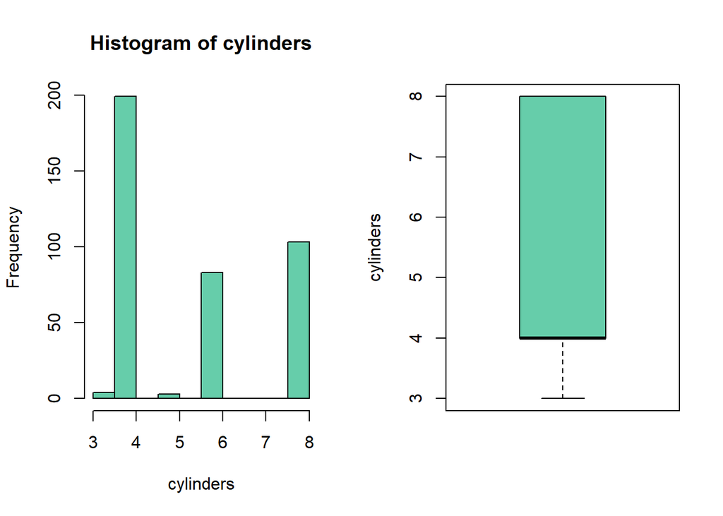

```r
par(mfrow = c(1, 2))
hist(datos$cylinders, xlab = "cylinders", main = "Histogram of cylinders", col = ("aquamarine3"))
boxplot(datos$cylinders, ylab = "cylinders", col = ("aquamarine3"))
```

```r
VMe2 <- mean(abs(datos$cylinders-median(datos$cylinders))) /median(datos$cylinders)
sprintf("The dispersion index is: %s",VMe2)
```

```
## [1] "The dispersion index is: 0.373086734693878"
```

#### **Displacement**

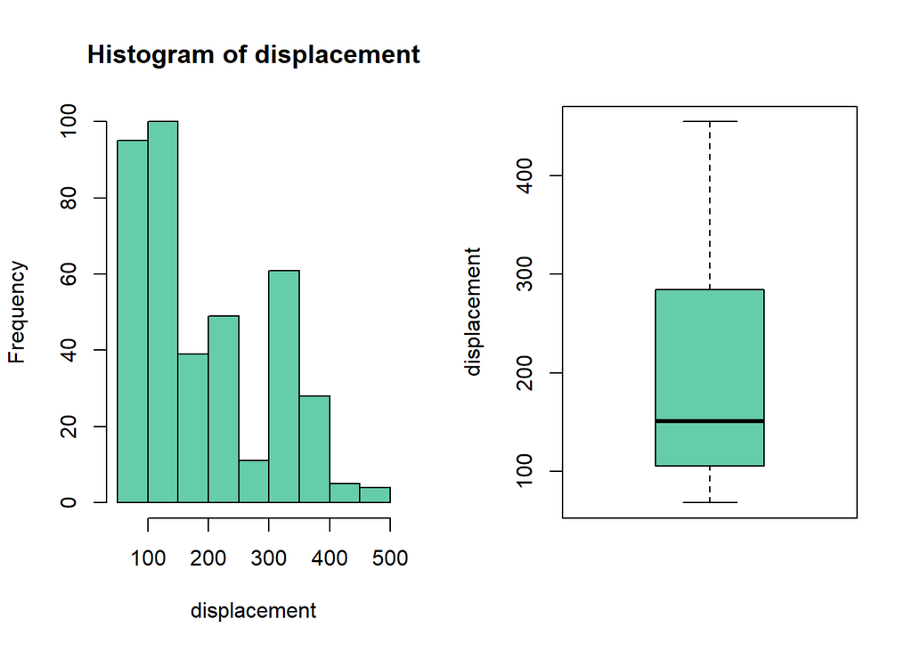

```r
par(mfrow = c(1, 2))
hist(datos$displacement, xlab = "displacement", main = "Histogram of displacement"
     , col = ("aquamarine3"))
boxplot(datos$displacement, ylab = "displacement", col = ("aquamarine3"))
```

```r
VMe3 <- mean(abs(datos$displacement-median(datos$displacement))) /median(datos$displacement)
sprintf("The dispersion index is: %s",VMe3)
```

```
## [1] "The dispersion index is: 0.578904243816732"
```

#### **Horsepower**

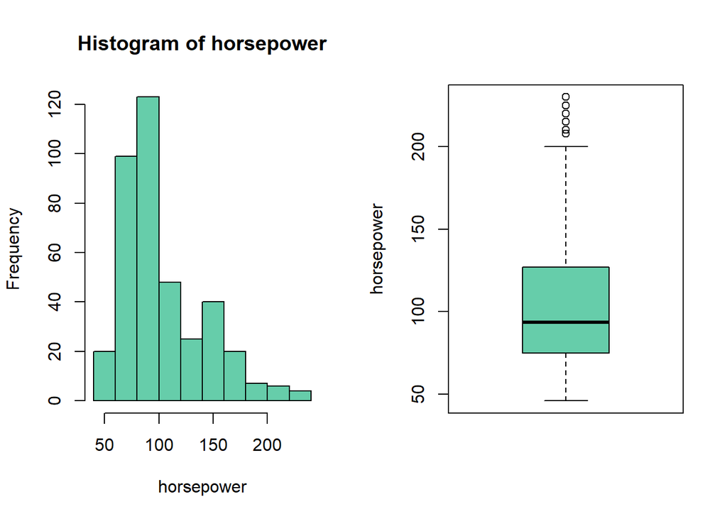

```r
par(mfrow = c(1, 2))
hist(datos$horsepower, xlab = "horsepower", main = "Histogram of horsepower"
     , col = ("aquamarine3"))
boxplot(datos$horsepower, ylab = "horsepower", col = ("aquamarine3"))
```

```r
VMe4 <- mean(abs(datos$horsepower-median(datos$horsepower))) /median(datos$horsepower)
sprintf("The dispersion index is: %s",VMe4)
```

```
## [1] "The dispersion index is: 0.306777256357088"
```

#### **Weight**

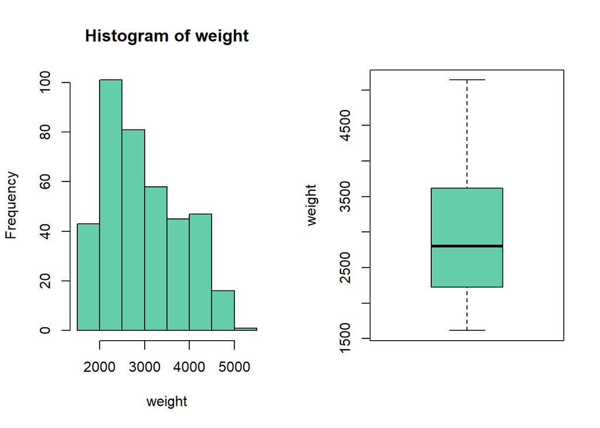

```r
par(mfrow = c(1, 2))
hist(datos$weight, xlab = "weight", main = "Histogram of weight"
     , col = ("aquamarine3"))
boxplot(datos$weight, ylab = "weight", col = ("aquamarine3"))
```

```r
VMe5 <- mean(abs(datos$weight-median(datos$weight))) /median(datos$weight)
sprintf("The dispersion index is: %s",VMe5)
```

```
## [1] "The dispersion index is: 0.254012841091493"
```

#### **Acceleration**

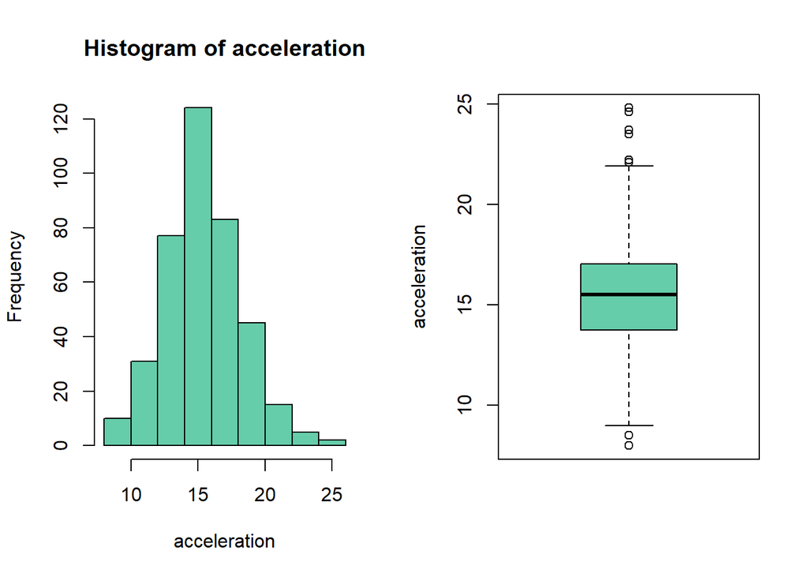

```r
par(mfrow = c(1, 2))
hist(datos$acceleration, xlab = "acceleration", main = "Histogram of acceleration"
     , col = ("aquamarine3"))
boxplot(datos$acceleration, ylab = "acceleration", col = ("aquamarine3"))
```

```r
VMe6 <- mean(abs(datos$acceleration-median(datos$acceleration))) /median(datos$acceleration)
sprintf("The dispersion index is: %s",VMe6)
```

```
## [1] "The dispersion index is: 0.137820934825543"
```

The acceleration data present a normal distribution, fairly symmetrical and with an average of around 16. The dispersion index is 0.137820934825543.

#### **Model year**

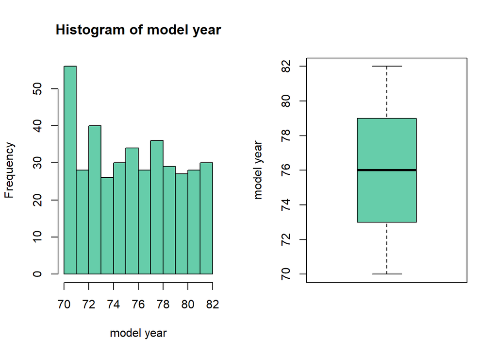

```r
par(mfrow = c(1, 2))
hist(datos$`model year`, xlab = "model year", main = "Histogram of model year"
     , col = ("aquamarine3"))
boxplot(datos$`model year`, ylab = "model year"
        , col = ("aquamarine3"))
```

```r
VMe7 <- mean(abs(datos$`model year`-median(datos$`model year`))) /median(datos$`model year`)
sprintf("The dispersion index is: %s",VMe7)
```

```
## [1] "The dispersion index is: 0.0415547798066595"
```

As for the model years of our samples, except for a peak in the 1970s, we can see that the distribution is uniform, with the mean according to the boxplot around the year 1976. And the dispersion index obtained is quite low 0.0415547798066595, so the representation of the median is considerable.

#### **Origin**

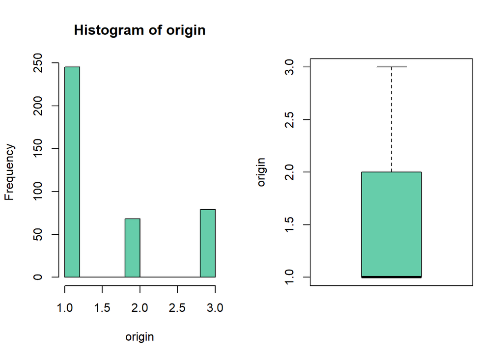

```r
par(mfrow = c(1, 2))
hist(datos$origin, xlab = "origin", main = "Histogram of origin"
     , col = ("aquamarine3"))
boxplot(datos$origin, ylab = "origin", col = ("aquamarine3"))
```

```r
VMe7 <- mean(abs(datos$origin-median(datos$origin))) /median(datos$origin)
sprintf("The dispersion index is: %s",VMe7)
```

```
## [1] "The dispersion index is: 0.576530612244898"
```

#### **Correlation matrix**

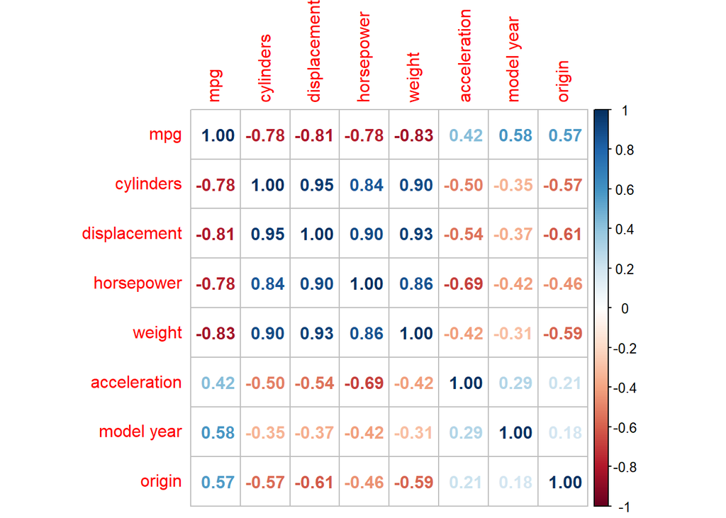

```r
library("corrplot")
corrplot(cor(datos[1:8]), method = "number")
```

The correlation coefficient is the specific measure that quantifies the strength of the linear relationship between two variables in a correlation analysis. The correlation coefficient is a unitless value between -1 and 1. The closer r is to zero, the weaker the linear relationship. Positive values indicate a positive correlation, where the values of both variables tend to increase together. Negative values indicate a negative correlation, where the values of one variable tend to increase while the values of the other variable decrease. Values of 1 and -1 represent a positive and negative “perfect” correlation, respectively. Here we can see for example, as we have seen before, that the ratio between displacement and weight is high. On the other hand we can see that the model year and the weight are hardly related. This matrix is very useful because at a glance we can see which variables are strongly related and which are hardly related.